# Read and transform examples - part 2

Andrew Singleton

16/02/2022

```r
library(harp)
library(here)
library(dplyr)
library(scico)
library(tidyr)
library(meteogrid)
library(forcats)
```

# Show the built in harp parameters

- Note that for FA files, parameters are hardcoded.

```r
show_param_defs()
```

```
## # A tibble: 60 × 2
##    name          description
##    <chr>         <chr>
##  1 accpcp12h     12-hour accumulated precipitation
##  2 accpcp1h      1-hour accumulated precipitation
##  3 accpcp24h     24-hour accumulated precipitation
##  4 accpcp3h      3-hour accumulated precipitation
##  5 accpcp6h      6-hour accumulated precipitation
##  6 caf           Cloud area fraction at vertical levels
##  7 cape          Convective available potential energy
##  8 cbase         Height of cloud base
##  9 cc_below_7500 Cloud cover below 7500m
## 10 cchigh        High level cloud cover
## 11 cclow         Low level cloud cover
## 12 ccmed         Medium level cloud cover
```

[output cut: 48 more lines]

```r
show_param_defs("grib")
```

```
## # A tibble: 50 × 2
##    name     grib_name
##    <chr>    <chr>
##  1 caf      tcc
##  2 cape     cape
##  3 cchigh   hcc
##  4 cclow    lcc
##  5 ccmed    mcc
##  6 cctot    tcc
##  7 d        wdir
##  8 d10m     wdir
##  9 g        fg
## 10 g10m     fg
## 11 gh       gh
## 12 lsm      lsm
```

[output cut: 38 more lines]

```r
show_param_defs("netcdf")
```

```
## # A tibble: 51 × 2
##    name     netcdf_name
##    <chr>    <chr>
##  1 caf      cloud_area_fraction
##  2 cape     specific_convective_available_potential_energy
##  3 cbase    cloud_base_altitude
##  4 cchigh   high_type_cloud_area_fraction
##  5 cclow    low_type_cloud_area_fraction
##  6 ccmed    medium_type_cloud_area_fraction
##  7 cctot    cloud_area_fraction
##  8 cin      atmosphere_convective_inhibition
##  9 d        wind_direction
## 10 d10m     wind_direction
## 11 g        wind_speed_of_gust
## 12 g10m     wind_speed_of_gust
```

[output cut: 39 more lines]

```r
show_param_defs("v")
```

```
## # A tibble: 35 × 2
##    name          v_name
##    <chr>         <chr>
##  1 accpcp12h     PE12
##  2 accpcp1h      PE1
##  3 accpcp24h     PE24
##  4 accpcp3h      PE3
##  5 accpcp6h      PE6
##  6 cbase         CH
##  7 cc_below_7500 N75
##  8 cchigh        HC
##  9 cclow         LC
## 10 ccmed         MC
## 11 cctot         NN
## 12 d             DD
```

[output cut: 23 more lines]

```r
show_param_defs("wrf")
```

```
## # A tibble: 22 × 2
##    name  wrf_name
##    <chr> <chr>
##  1 caf   CLDFRA
##  2 cctot CLDFRA
##  3 gh    Z
##  4 lsm   LANDMASK
##  5 pcp   list(RAINNC, RAINC)
##  6 q     QVAPOR
##  7 q2m   Q2
##  8 sst   SST
##  9 t     T
## 10 t0m   TSK
## 11 t2m   T2
## 12 topo  HGT
## 13 u     U
## 14 u10m  U10
## 15 v     V
## 16 v10m  V10
## 17 w     W
## 18 wd    list(u = U, v = V)
## 19 wd10m list(u = U10, v = V10)
## 20 ws    list(u = U, v = V)
## 21 ws10m list(u = U10, v = V10)
## 22 z     PH
```

# Read in U10m and V10m

and get the wind speed using “ws10m”

```r
template <- "{fcst_model}/wind/{YYYY}/{MM}/{DD}/{HH}/mbr{MBR3}/fc{YYYY}{MM}{DD}{HH}+{LDT3}grib"
ws10m <- read_forecast(
  dttm          = 2021012100,
  fcst_model    = "AAEPS",
  parameter     = "WS10m",
  lead_time     = 0,
  members       = 0,
  file_path     = here("data/grib"),
  file_template = template,
  return_data   = TRUE
)

u10m <- read_forecast(
  dttm          = 2021012100,
  fcst_model    = "AAEPS",
  parameter     = "U10m",
  lead_time     = 0,
  members       = 0,
  file_path     = here("data/grib"),
  file_template = template,
  return_data   = TRUE
)

v10m <- read_forecast(
  dttm          = 2021012100,
  fcst_model    = "AAEPS",
  parameter     = "V10m",
  lead_time     = 0,
  members       = 0,
  file_path     = here("data/grib"),
  file_template = template,
  return_data   = TRUE
)
u10m
```

```
## ::ensemble gridded forecast:: # A tibble: 1 × 11
##   fcst_model fcst_dttm           lead_time parameter valid_dttm
##   <chr>      <dttm>                  <dbl> <chr>     <dttm>
## 1 AAEPS      2021-01-21 00:00:00         0 U10m      2021-01-21 00:00:00
## # ℹ 6 more variables: step_range <chr>, level_type <chr>, level <int>,
## #   units <chr>, fcst_cycle <chr>, AAEPS_mbr000 <geolist>
```

We can check the results by plotting

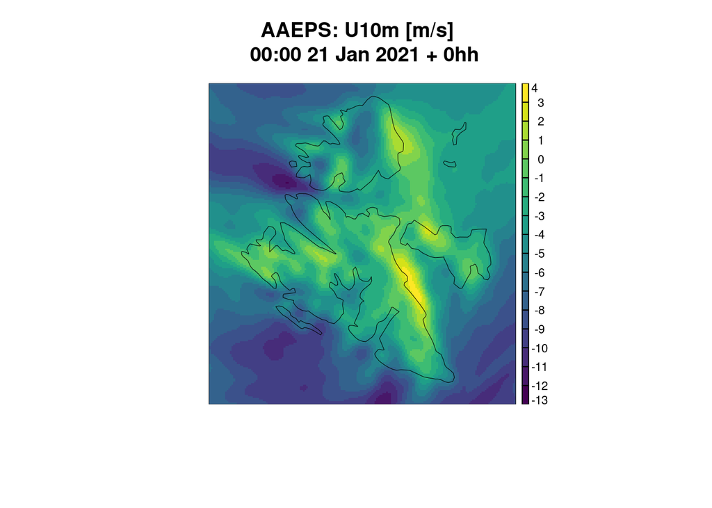

```r
plot_field(u10m, plot_col = AAEPS_mbr000)
```

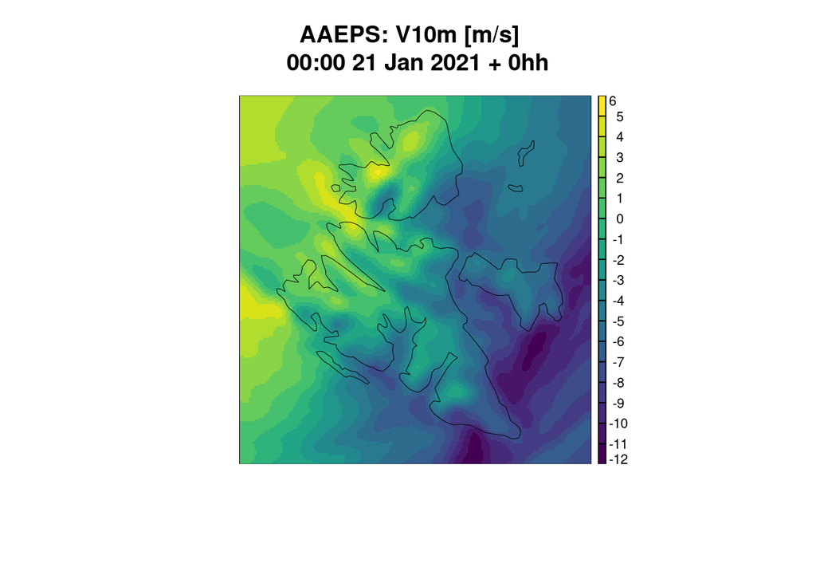

```r
plot_field(v10m, plot_col = AAEPS_mbr000)
```

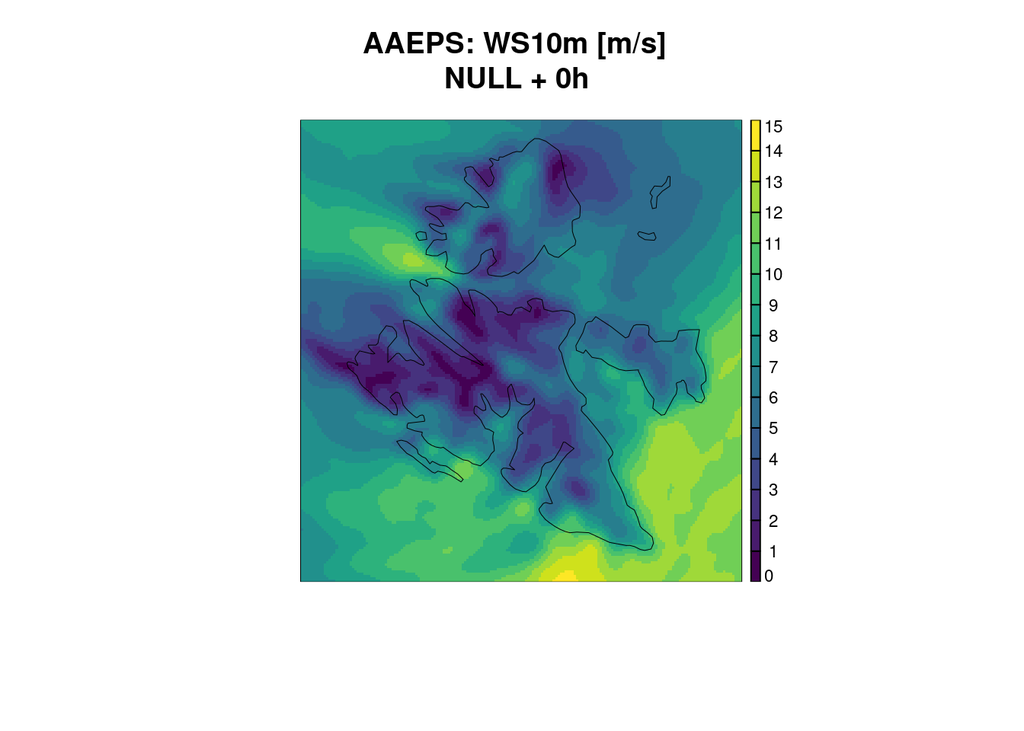

```r
plot_field(ws10m, plot_col = AAEPS_mbr000)
```

[output not shown]

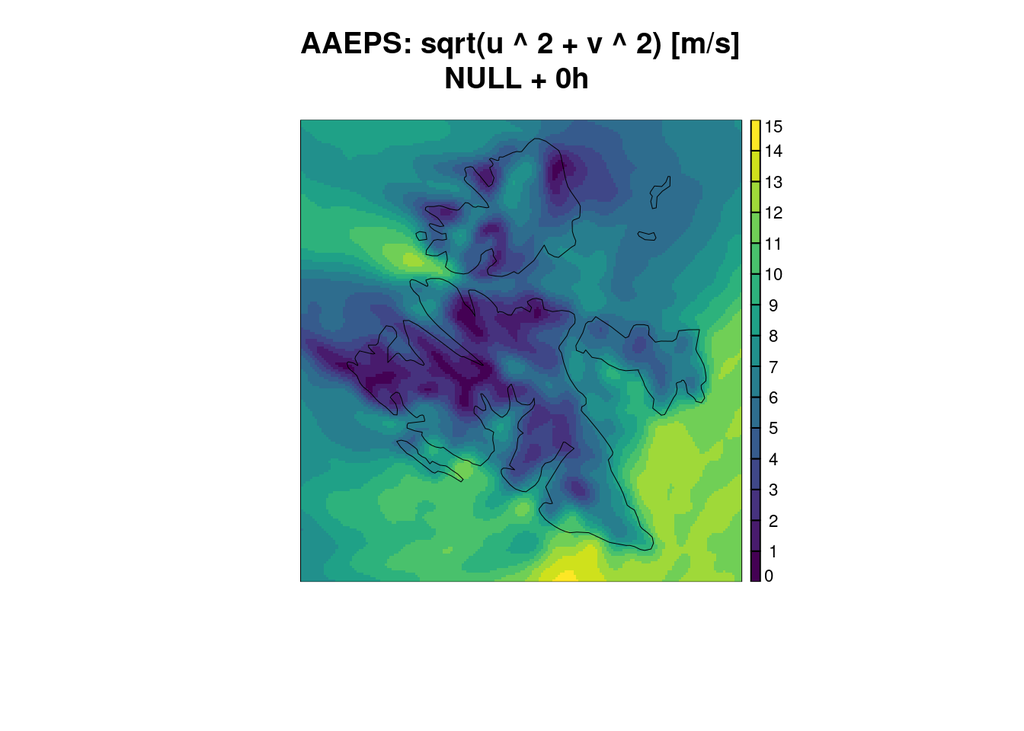

```r
plot_field(
  mutate(
    inner_join(
      rename(u10m, u = AAEPS_mbr000),
      select(rename(v10m, v = AAEPS_mbr000), -parameter)
    ),
    AAEPS_mbr000 = geolist(sqrt(u ^ 2 + v ^ 2)),
    parameter = "sqrt(u ^ 2 + v ^ 2)"
  ),
  plot_col = AAEPS_mbr000
)
```

Read a radar analysis (note this is over 1Gb of data - check you have enough memory)

```r
template <- paste0(
  "{fcst_model}/{YYYY}/{MM}/norway.mos.sri-acrr-1h.noclass-clfilter-",
  "vpr-clcorr-block.utm33-1000.{YYYY}{MM}{DD}.nc"
)
radar <- read_analysis(
  dttm             = seq_dttm(2022021200, 2022021323),
  analysis_model   = "radar",
  parameter        = "lwe_precipitation_rate",
  file_template    = template,
  file_path        = here("data/netcdf"),
  file_format_opts = netcdf_opts(
    proj4_var = "projection_utm",
    x_dim     = "Xc",
    y_dim     = "Yc",
    lon_var   = "lon",
    lat_var   = "lat",
    y_rev     = TRUE
  )
)
```

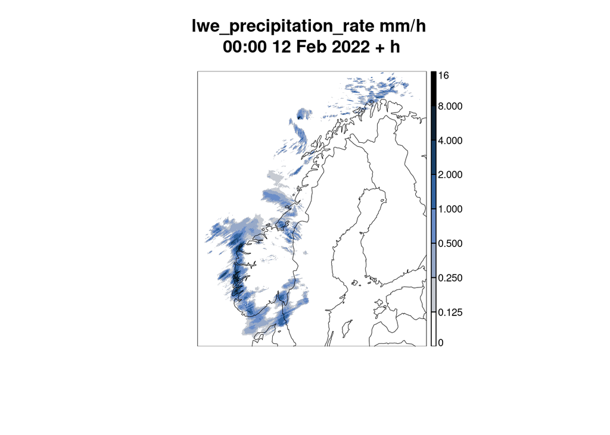

```r
plot_field(
  radar$anl[[23]],
  breaks = c(0, 0.125, 0.25, 0.5, 1, 2, 4, 8, 16),
  palette = c(
    "transparent", scico(255, palette = "oslo", direction = -1)
  )
)
```

# Read point observations

Use `read_obs()` in the same way as `read_forecast()`. Currently only works for vobs, so the file template is set to vobs by default - only need the dates and the path.

```r
obs <- read_obs(
  dttm        = seq_dates(2019021700, 2019021723),
  file_path   = here("data/vobs"),
  return_data = TRUE
)
obs
```

```
## $synop
## # A tibble: 80,598 × 24
##    valid_dttm            SID   lat   lon  elev CCtot  D10m  S10m   T2m  Td2m
##    <dttm>              <int> <dbl> <dbl> <dbl> <dbl> <dbl> <dbl> <dbl> <dbl>
##  1 2019-02-17 00:00:00  1001  70.9 -8.67     9  8      202   8.8  270.  268.
##  2 2019-02-17 00:00:00  1002  80.1 16.2      8 NA      330  13    248.  246
##  3 2019-02-17 00:00:00  1003  77   15.5     10  1.04    30   2    252.  245.
##  4 2019-02-17 00:00:00  1006  78.3 22.8     14 NA       20   3    247.  244.
##  5 2019-02-17 00:00:00  1007  78.9 11.9      8 NA      350   5    250.   NA
##  6 2019-02-17 00:00:00  1008  78.2 15.5     27  7.04   298   7.6  251.  246
##  7 2019-02-17 00:00:00  1009  80.7 25.0      5 NA      330  12    244.  241.
##  8 2019-02-17 00:00:00  1010  69.3 16.1     13 NA      340  11.3  274.  268.
##  9 2019-02-17 00:00:00  1011  80.1 31.5      9 NA      352  11.4  240.  236.
## 10 2019-02-17 00:00:00  1013  78.1 13.6    -99 NA       NA  NA     NA    NA
## # ℹ 80,588 more rows
## # ℹ 14 more variables: RH2m <dbl>, Q2m <dbl>, Ps <dbl>, Pmsl <dbl>, vis <dbl>,
## #   AccPcp3h <dbl>, AccPcp6h <dbl>, AccPcp24h <dbl>, N75 <int>, CClow <int>,
## #   Cbase <int>, AccPcp1h <dbl>, Gmax <dbl>, AccPcp12h <dbl>
##
## $synop_params
##    parameter accum_hours   units
## 1      CCtot           0   oktas
## 2       D10m           0 degrees
## 3       S10m           0     m/s
## 4        T2m           0       K
## 5       Td2m           0       K
## 6       RH2m           0 percent
## 7        Q2m           0   kg/kg
## 8         Ps           0     hPa
## 9       Pmsl           0     hPa
## 10       vis           0       m
## 11  AccPcp3h           3  kg/m^2
## 12  AccPcp6h           6  kg/m^2
## 13 AccPcp24h          24  kg/m^2
## 14       N75           0   oktas
## 15     CClow           0   oktas
## 16     Cbase           0       m
## 17  AccPcp1h           1  kg/m^2
## 18      Gmax           0     m/s
## 19 AccPcp12h          12  kg/m^2
```

[output cut: 13 more lines]

```
##  9 2019-02-17 00:00:00  1001  70.9 -8.67     9   200 11220  218.   2.9   262
## 10 2019-02-17 00:00:00  1001  70.9 -8.67     9   150 13048  217.   2.5   257
## # ℹ 37,862 more rows
## # ℹ 3 more variables: S <dbl>, Q <dbl>, Td <dbl>
##
## $temp_params
##   parameter accum_hours   units
## 1         p           0     hPa
## 2         Z           0       m
## 3         T           0       K
## 4        RH           0 percent
## 5         D           0 degrees
## 6         S           0     m/s
## 7         Q           0   kg/kg
## 8        Td           0       K
```

We can easily plot some synop data on a map

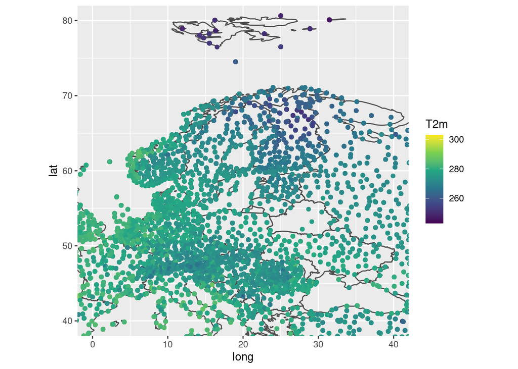

```r
ggplot(drop_na(obs$synop, T2m)) +
  geom_polygon(
    aes(x = long, y = lat, group = group),
    map_data("world"),
    fill   = NA,
    colour = "grey30"
  ) +
  geom_point(aes(x = lon, y = lat, colour = T2m)) +
  coord_equal(
    xlim = c(0, 40),
    ylim = c(40, 80)
  ) +
  scale_colour_viridis_c(limits = c(243, 303))
```

# Transformations

harp’s read functions allow you to transform data as it is read in. That is to say, it can interpolate gridded data to geographic points, regrid and reproject gridded data and make a vertical cross section from 3d gridded data. These are activated through the `transformation` argument to `read_grid()`, `read_forecast()` and `read_analysis()`. Special options for each transformation are passed via the `transformation_opts` argument, with each transforamtion having it’s own function to set those options.

## Interpolation to points.

By default this is done using harp’s built in station list

```r
station_list
```

```
## # A tibble: 13,417 × 5
##      SID   lat   lon  elev name
##    <int> <dbl> <dbl> <dbl> <chr>
##  1  1001  70.9 -8.67   9.4 JAN MAYEN
##  2  1002  80.1 16.2    8   VERLEGENHUKEN
##  3  1003  77   15.5   11.1 HORNSUND
##  4  1004  78.9 11.9    8   NY-ALESUND II
##  5  1006  78.3 22.8   14   EDGEOYA
##  6  1007  78.9 11.9    7.7 NY-ALESUND
##  7  1008  78.2 15.5   26.8 SVALBARD AP
##  8  1009  80.7 25.0    5   KARL XII OYA
##  9  1010  69.3 16.1   13.1 ANDOYA
## 10  1011  80.1 31.5   10   KVITOYA
## # ℹ 13,407 more rows
```

Also, if there is sufficient data available (surface geopotential or topography height), 2m temperature can be corrected to take account of the difference in model elevation and the actual elevation of the station.

Use `transformation = "interpolate"` and `interpolate_opts()`. All options have default values, so it isn’t always necessary to set anything

```r
interpolate_opts()
```

```
## No stations specified. Using default stations: 'station_list'
```

```
## $stations
## # A tibble: 13,417 × 5
##      SID   lat   lon  elev name
##    <int> <dbl> <dbl> <dbl> <chr>
##  1  1001  70.9 -8.67   9.4 JAN MAYEN
##  2  1002  80.1 16.2    8   VERLEGENHUKEN
##  3  1003  77   15.5   11.1 HORNSUND
##  4  1004  78.9 11.9    8   NY-ALESUND II
##  5  1006  78.3 22.8   14   EDGEOYA
##  6  1007  78.9 11.9    7.7 NY-ALESUND
##  7  1008  78.2 15.5   26.8 SVALBARD AP
##  8  1009  80.7 25.0    5   KARL XII OYA
##  9  1010  69.3 16.1   13.1 ANDOYA
## 10  1011  80.1 31.5   10   KVITOYA
## # ℹ 13,407 more rows
##
## $method
## [1] "nearest"
##
## $correct_t2m
## [1] TRUE
##
## $keep_model_t2m
## [1] FALSE
##
## $lapse_rate
## [1] 0.0065
##
## $clim_file
## NULL
##
## $clim_file_format
## NULL
##
## $clim_file_opts
## NULL
##
## $clim_param
## [1] "sfc_geo"
##
## $use_mask
## [1] FALSE
##
## $weights
## NULL
##
## $keep_raw_data
## [1] FALSE
```

We can simply run `read_forecast()` as before and interpolate to stations to the default stations using `transformation = “interpolate”

```r
template <- "{fcst_model}/{YYYY}/{MM}/{DD}/{HH}/mbr{MBR3}/fc{YYYY}{MM}{DD}{HH}+{LDT3}grib"
t2m <- read_forecast(
  dttm           = seq_dttm(2021012100, 2021012200, "1d"),
  fcst_model     = "AAEPS",
  parameter      = "T2m",
  lead_time      = seq(0, 24, 3),
  members        = seq(0, 3),
  transformation = "interpolate",
  file_path      = here("data/grib"),
  file_template  = template,
  return_data    = TRUE
)
```

```
## No stations specified. Using default stations: 'station_list'
```

```
## Initializing interpolate weights using 'sfc_geo'.
```

```
## Reading /home/andrewts/harp-documentation/md/harp_training_2022/data/grib/AAEPS/2021/01/21/00/mbr000/fc2021012100+000grib
```

```
## Error : None of the requested data could be read from grib file: /home/andrewts/harp-documentation/md/harp_training_2022/data/grib/AAEPS/2021/01/21/00/mbr000/fc2021012100+000grib
```

```
## Error: 2m temperature height correction is selected, but cannot find 'sfc_geo' in /home/andrewts/harp-documentation/md/harp_training_2022/data/grib/AAEPS/2021/01/21/00/mbr000/fc2021012100+000grib.
## You probably need to set transformation_opts = interpolate_opts(clim_file = '<clim_file>', clim_param = '<clim_param>'), or switch off 2m temperature correction with transformation_opts = interpolate_opts(correct_t2m = FALSE).
```

We don’t actually have the correct data available to do the height correction of 2m temperature so we can switch it off via `interpolate_opts()`

```r
t2m <- read_forecast(
  dttm           = seq_dttm(2021012100, 2021012200, "1d"),
  fcst_model     = "AAEPS",
  parameter      = "T2m",
  lead_time      = seq(0, 3, 3),
  members        = seq(0, 1),
  transformation = "interpolate",
  transformation_opts = interpolate_opts(
    correct_t2m = FALSE
  ),
  file_path      = here("data/grib"),
  file_template  = template,
  return_data    = TRUE
)
```

[output not shown]

```r
t2m
```

```
## ::ensemble point forecast:: # A tibble: 48 × 15
##    fcst_model fcst_dttm           lead_time parameter valid_dttm
##    <chr>      <dttm>                  <dbl> <chr>     <dttm>
##  1 AAEPS      2021-01-21 00:00:00         0 T2m       2021-01-21 00:00:00
##  2 AAEPS      2021-01-21 00:00:00         0 T2m       2021-01-21 00:00:00
##  3 AAEPS      2021-01-21 00:00:00         0 T2m       2021-01-21 00:00:00
##  4 AAEPS      2021-01-21 00:00:00         0 T2m       2021-01-21 00:00:00
##  5 AAEPS      2021-01-21 00:00:00         0 T2m       2021-01-21 00:00:00
##  6 AAEPS      2021-01-21 00:00:00         0 T2m       2021-01-21 00:00:00
##  7 AAEPS      2021-01-21 00:00:00         0 T2m       2021-01-21 00:00:00
##  8 AAEPS      2021-01-21 00:00:00         0 T2m       2021-01-21 00:00:00
##  9 AAEPS      2021-01-21 00:00:00         0 T2m       2021-01-21 00:00:00
## 10 AAEPS      2021-01-21 00:00:00         0 T2m       2021-01-21 00:00:00
## # ℹ 38 more rows
## # ℹ 10 more variables: step_range <chr>, level_type <chr>, level <int>,
## #   units <chr>, SID <int>, lat <dbl>, lon <dbl>, fcst_cycle <chr>,
## #   AAEPS_mbr000 <dbl>, AAEPS_mbr001 <dbl>
```

## Regridding to a different grid

We can use any geofield (or geodomain) as a reference to regrid the data to. Now we set `transformation = "regrid")` and we use `regrid_opts()` to set the options. Note that `regrid_opts()` must have a `new_domain` argument.

Let’s read the radar data in again, but this time regrid it to the domain from the netcdf file we had with precipitation.

```r
domain <- get_domain(
  read_grid(
    here("data/netcdf/meps/2022/02/12/meps_lagged_6_h_subset_2_5km_20220212T00Z.nc"),
    "pcp",
    lead_time = 0,
    members   = 0,
    file_format_opts = netcdf_opts(
      ref_time_var = "forecast_reference_time",
      member_var   = "ensemble_member",
      z_var        = "height0"
    )
  )
)
```

```
## Reading /home/andrewts/harp-documentation/md/harp_training_2022/data/netcdf/meps/2022/02/12/meps_lagged_6_h_subset_2_5km_20220212T00Z.nc
```

```r
regrid_opts(new_domain = domain)
```

```
## $new_domain
## 121 x 206 domain
## Projection summary:
## proj= lcc
## NE = ( 9.38741 , 62.7829 )
## SW = ( 5.104273 , 57.8871 )
##
## $method
## [1] "nearest"
##
## $clim_file
## NULL
##
## $clim_file_format
## NULL
##
## $clim_file_opts
## NULL
##
## $clim_param
## [1] "sfc_geo"
##
## $weights
## NULL
##
## $keep_raw_data
## [1] FALSE
```

Now we can simply regrid the radar data as we read it in

```r
template <- paste0(
  "{fcst_model}/{YYYY}/{MM}/norway.mos.sri-acrr-1h.noclass-clfilter-",
  "vpr-clcorr-block.utm33-1000.{YYYY}{MM}{DD}.nc"
)
radar <- read_analysis(
  dttm                = seq_dttm(2022021300, 2022021323),
  analysis_model      = "radar",
  parameter           = "lwe_precipitation_rate",
  transformation      = "regrid",
  transformation_opts = regrid_opts(new_domain = domain),
  file_template       = template,
  file_path           = here("data/netcdf"),
  file_format_opts    = netcdf_opts(
      proj4_var = "projection_utm",
      x_dim     = "Xc",
      y_dim     = "Yc",
      lon_var   = "lon",
      lat_var   = "lat",
      y_rev     = TRUE
  )
)
```

[output not shown]

And now we can plot

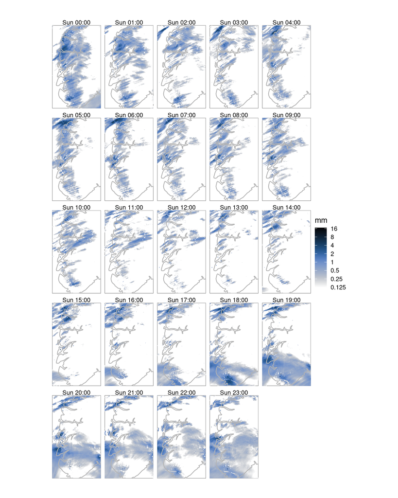

```r
ggplot(radar) +
  geom_georaster(aes(geofield = anl)) +
  geom_polygon(
    aes(x, y, group = group),
    get_map(domain),
    fill = NA,
    colour = "grey70"
  ) +
  scale_fill_scico(
    "mm",
    palette   = "oslo",
    direction = -1,
    limits    = c(0.125, NA),
    na.value  = NA,
    trans     = "log",
    breaks    = c(0.125, 0.25, 0.5, 1, 2, 4, 8, 16),
    labels    = c(0.125, 0.25, 0.5, 1, 2, 4, 8, 16)
  ) +
  facet_wrap(vars(fct_inorder(format(valid_dttm, "%a %H:%M")))) +
  coord_equal(expand = FALSE) +
  theme_void() +
  theme(
    plot.margin      = unit(c(1, 1, 1, 1), "cm"),
    panel.background = element_rect(fill = NA, colour = "grey30")
  )
```

# Vertical Cross Sections

Vertical cross sections are extracted using `transformation = "xsection"` and `transformation_opts = xsection_opts(a = ..., b = ...)` where `a` and `b` are the lon-lat locations of the ends of the cross section.

```r
xs <- read_grid(
  here("data/grib/AAEPS/2021/01/21/00/mbr000/fc2021012100+000grib"),
  "T",
  vertical_coordinate = "model",
  transformation      = "xsection",
  transformation_opts = xsection_opts(
    a = c(7.76, 78.49), b = c(28.25, 79.29)
  )
)
```

```
## Reading /home/andrewts/harp-documentation/md/harp_training_2022/data/grib/AAEPS/2021/01/21/00/mbr000/fc2021012100+000grib
```

```
## Computing interpolation weights for xsectioning.
```

A data frame is returned (or in the case of `read_forecast` a data frame with a column having a list of data frames), so can easily plot with geom_raster()

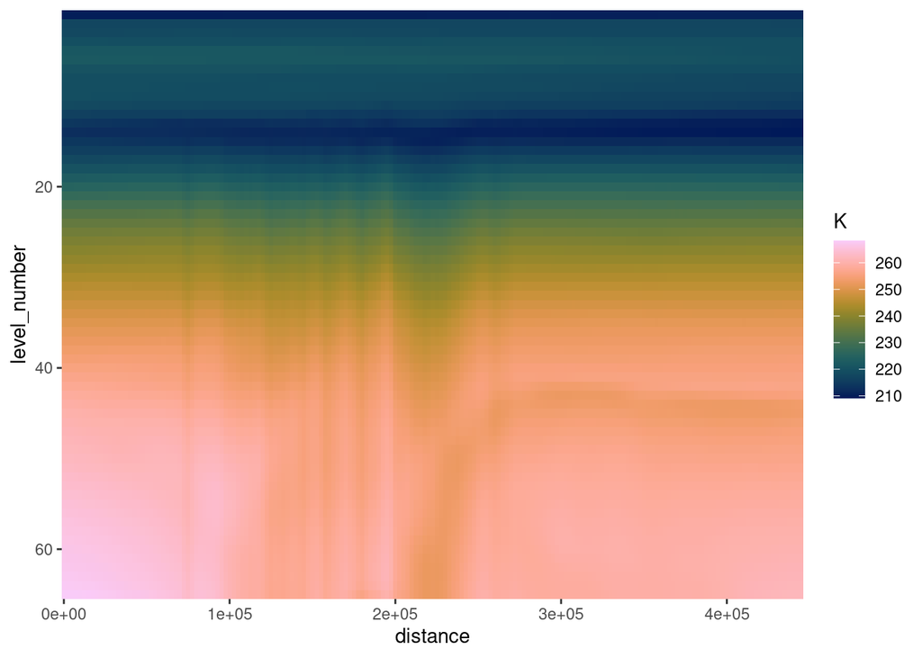

```r
ggplot(xs, aes(distance, level_number, fill = value)) +
  geom_raster() +
  scale_fill_scico("K", palette = "batlow") +
  scale_y_reverse() +
  coord_cartesian(expand = FALSE)
```

The cross sections are oriented from a to b, so if we reverse a and b everything will be the other way around.

```r
xs <- read_grid(
  here("data/grib/AAEPS/2021/01/21/00/mbr000/fc2021012100+000grib"),
  "T",
  vertical_coordinate = "model",
  transformation      = "xsection",
  transformation_opts = xsection_opts(
    b = c(7.76, 78.49), a = c(28.25, 79.29)
  )
)
```

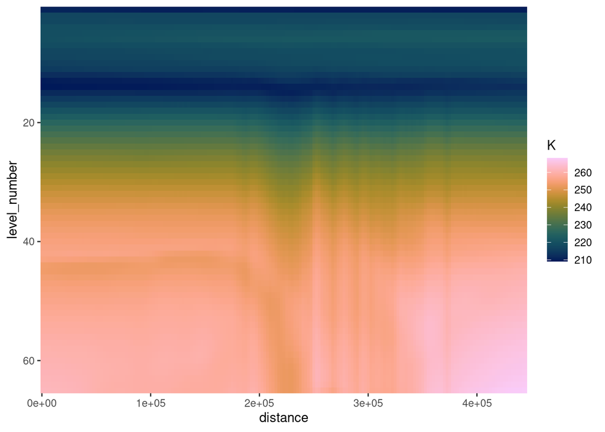

```r
ggplot(xs, aes(distance, level_number, fill = value)) +
  geom_raster() +
  scale_fill_scico("K", palette = "batlow") +
  scale_y_reverse() +
  coord_cartesian(expand = FALSE)
```